# simon-5501-02-slides

2026-09-01

## Topics to be covered

- What you will learn
  - Counts and percentages
  - Computing counts and percentages using R
  - Mean and median
  - Percentiles
  - Standard deviation
  - Computing means and standard deviations in R

## Count the occurrences of the letter “e”.

```
A quality control program is easiest
to implement from the top down.
Make sure that you understand the
the commitment of time and money
that is involved. Every workplace is
different, but think about allocating
10% of your time and 10% of the
time of all your employees to
quality control.
```

## A practical counting example

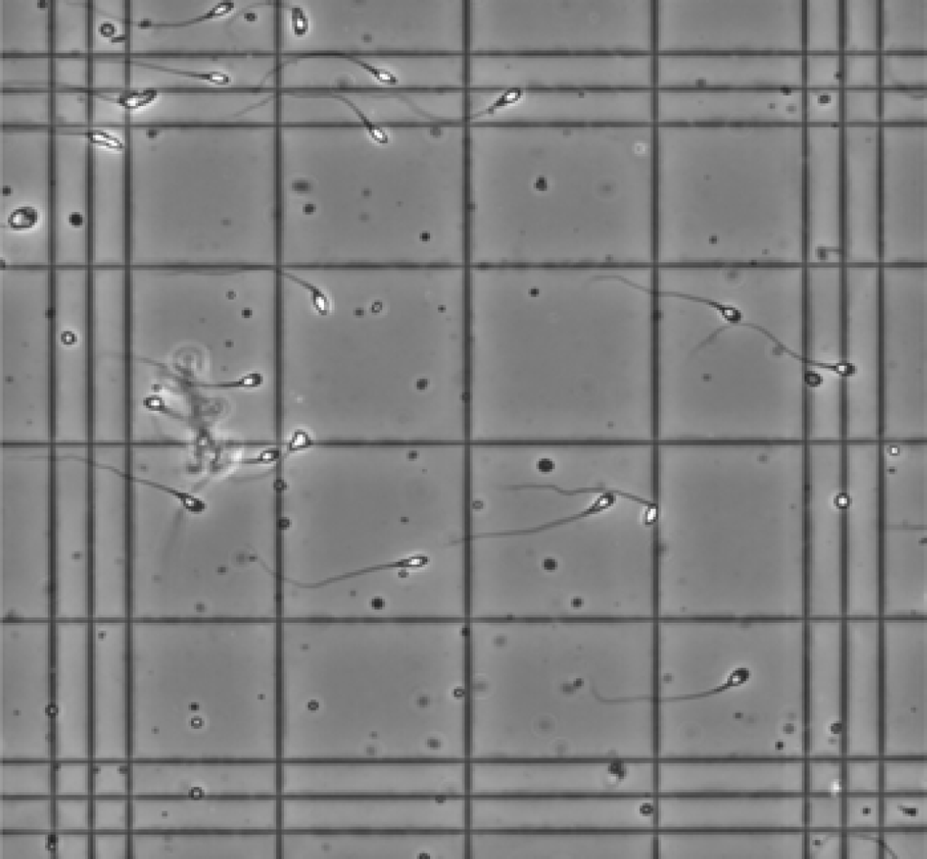

Image of a haemocytometer

## Measurement error

- Imprecision in a physical measurement
  - Example: GPS location
    - Can be off by up to 8 meters
    - Worse around large buildings
  - Other examples
    - Weight
    - Body temperature
    - Blood glucose

## Reducing measurement error

- Calibration
- Consistent environment
- Good equipment
- Quality control
- Training

## Errors of validity

- Mostly used for constructs
- Types of validity
  - Criterion
    - Concurrent
    - Predictive
  - Content/face
  - Many others
- Re-establishing validity

## Errors of reliability

- Synonym: repeatability(?)
- Not reproducibility
- Both physical measurements and constructs
- Types of reliability
  - Test-retest
  - Inter-rater
  - Inter-method

## Errors due to sampling

- To be covered later
- Easiest to quantify
- Less important in era of big data

## Break #1

- What you have learned
  - Counts and percentages
- What’s coming next
  - Computing counts and percentages using R

## Live demo, part 1

## Break #2

- What you have learned
  - Computing counts and percentages using R
- What’s coming next
  - Mean and median

## Calculation of the mean and median

- Mean
  - Add up all the values, divide by the sample size
- Median
  - Sort the data
    - Select the middle value if n is odd
    - go halfway between the two middle values if n is even

## Formal mathematical definitions

- Mean
  - $\bar{X}=\frac{1}{n}\Sigma X_i$
- Median
  - Sorted values $X_{[1]},X_{[2]},...,X_{[n]}$
    - $X_{[(n+1)/2]}$ if n is odd,
    - $(X_{[n/2]}+X_{[n/2+1]})/2$ if n is even

## Bacteria before and after A/C upgrade

```
  room before after
1  121   11.8  10.1
2  163    8.2   7.2
3  125    7.1   3.8
4  264   14.0  12.0
5  233   10.8   8.3
6  218   10.1  10.5
7  324   14.6  12.1
8  325   14.0  13.7
```

## Calculation of the before mean

$\frac{1}{8}(11.8+8.2+7.1+14+10.8+10.1+14.6+14)$

$= \frac{1}{8}(90.6)$

$= 11.325$

The average colony count per cubic foot before remediation, 11.3, is quite large.

## Calculation of the after mean

$\frac{1}{8}(10.1+7.2+3.8+12+8.3+10.5+12.1+13.7)$

$= \frac{1}{8}(77.7)$

$= 9.7125$

The average colony count per cubic foot after remediation, 9.7, is smaller, but still quite large.

## Calculation of the median

- Sort your data from low to high
- Select the middle observation(s)
  - If n is odd
    - Choose the (n+1)/2 observation
  - If n is even(n/2) and (n/2 + 1) if n is even
    - Go halfway between (n/2) and (n/2 + 1) observation

## Calculate the before median, 1

Here is the sorted data.

```
  room before
1  125    7.1
2  163    8.2
3  218   10.1
4  233   10.8
5  121   11.8
6  264   14.0
7  325   14.0
8  324   14.6
```

## Calculate the before median, 2

Here are the middle two observations

```
  room before middle
1  125    7.1
2  163    8.2
3  218   10.1
4  233   10.8   10.8
5  121   11.8   11.8
6  264   14.0
7  325   14.0
8  324   14.6
```

## Calculate the before median, 3

Average the two middle observations

```
  room before middle median
1  125    7.1
2  163    8.2
3  218   10.1
4  233   10.8   10.8   11.3
5  121   11.8   11.8
6  264   14.0
7  325   14.0
8  324   14.6
```

## Calculate the after median, 1

Here is the sorted data.

```
  room after
1  125   3.8
2  163   7.2
3  233   8.3
4  121  10.1
5  218  10.5
6  264  12.0
7  324  12.1
8  325  13.7
```

## Calculate the after median, 2

Here are the middle two observations

```
  room after middle
1  125   3.8
2  163   7.2
3  233   8.3
4  121  10.1   10.1
5  218  10.5   10.5
6  264  12.0
7  324  12.1
8  325  13.7
```

## Calculate the after median, 3

Average the two middle observations

```
  room after middle median
1  125   3.8
2  163   7.2
3  233   8.3
4  121  10.1   10.1   10.3
5  218  10.5   10.5
6  264  12.0
7  324  12.1
8  325  13.7
```

## Criticisms of the mean and median

- Are you combining apples and onions?
- Are you ignoring minorities?

[figure not shown]

Excerpt from Gould 1985 publication

## Choosing between the mean and median

- Often, either is fine
- When do you use the mean?
  - When totals are important
  - “In 2020, the average expenditure by the Italian National Health Service (Servizio Sanitario Nazionale, SSN) per patient affected by at least one chronic disease was approximately 696 euros.”
- When do you use the median
  - When outliers/skewness might distort your conclusions

[figure not shown]

Chen et al 2019

## Chen 2019, PMID: 31806195 (continued)

Background: The prices of newly approved cancer drugs have risen over the past decades. **A key policy question is whether the clinical gains offered by these drugs in treating specific cancer indications justify the price increases.**

## Chen 2019, PMID: 31806195 (continued)

Results: We found that between 1995 and 2012, price increases outstripped median survival gains, a finding consistent with previous literature. **Nevertheless, price per mean life-year gained increased at a considerably slower rate, suggesting that new drugs have been more effective in achieving longer-term survival.** Between 2013 and 2017, price increases reflected equally large gains in median and mean survival, resulting in a flat profile for benefit-adjusted launch prices in recent years.

## Break #3

- What you have learned
  - Mean and median
- What’s coming next
  - Percentiles

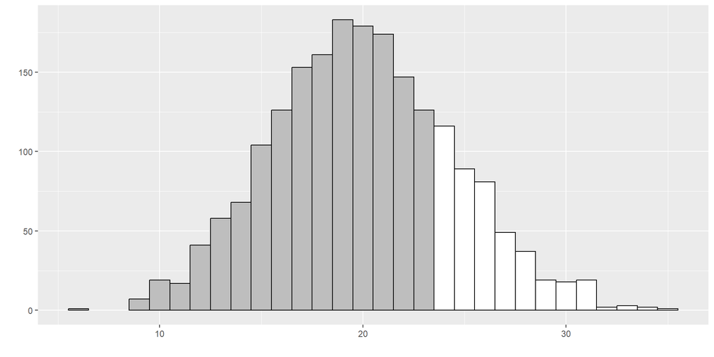

## Computing percentiles

- Many formulas
  - Differences are not worth fighting over
- My preference (pth quantile)
  - Sort the data
  - Calculate p*(n+1)
  - Is it a whole number?
    - Yes: Select that value, otherwise
    - No: Go halfway between
    - Special cases: p(n+1) < 1 or > n

## Some examples of percentile calculations

- Example for n=39
  - For 5th percentile, p(n+1)=2 -> 2nd smallest value
  - For 4th percentile, p(n+1)=1.6 -> halfway between two smallest values
  - For 2nd percentile, p(n+1)=0.8 -> smallest value

## Some terminology

- Percentile: goes from 0% to 100%
- Quantile: goes from 0.0 to 1.0
  - 90th percentile = 0.9 quantile
- 25th, 50th, and 75th percentiles: quartiles
  - 25th percentile: $Q_1,\ X_{0.25}$ or lower quartile
  - Median/50th percentiles: $Q_2$ or $X_{0.5}$
  - 75th percentile: $Q_3,\ X_{0.75}$ or upper quartile

## Calculate before remediation upper quartile, 1

Here is the sorted data.

```
  room before
1  125    7.1
2  163    8.2
3  218   10.1
4  233   10.8
5  121   11.8
6  264   14.0
7  325   14.0
8  324   14.6
```

## Calculate before remediation upper quartile, 2

Calculate 0.75*(8+1) = 6.75. Select the 6th and 7th observations

```
  room before pick
1  125    7.1
2  163    8.2
3  218   10.1
4  233   10.8
5  121   11.8
6  264   14.0   14
7  325   14.0   14
8  324   14.6
```

## Calculate before remediation upper quartile, 3

Average the two observations

```
  room before pick   q3
1  125    7.1
2  163    8.2
3  218   10.1
4  233   10.8
5  121   11.8
6  264   14.0   14   14
7  325   14.0   14
8  324   14.6
```

## Calculate after remediation upper quartile, 1

Here is the sorted data.

```
  room after
1  125   3.8
2  163   7.2
3  233   8.3
4  121  10.1
5  218  10.5
6  264  12.0
7  324  12.1
8  325  13.7
```

## Calculate after remediation upper quartile, 2

Calculate 0.75*(8+1) = 6.75. Select the 6th and 7th observations

```
  room after pick
1  125   3.8
2  163   7.2
3  233   8.3
4  121  10.1
5  218  10.5
6  264  12.0   12
7  324  12.1 12.1
8  325  13.7
```

## Calculate after remediation upper quartile, 3

Average the two observations

```
  room after pick    q3
1  125   3.8
2  163   7.2
3  233   8.3
4  121  10.1
5  218  10.5
6  264  12.0   12 12.05
7  324  12.1 12.1
8  325  13.7
```

## When you should use percentiles

- Characterize variation
  - Middle 50% of the data
- Exposure issues
  - Not enough to control median exposure level
- Quantify extremes
  - What does “upper class” mean?
- Quality control
  - Almost all products must meet a minimum standard

## Break #4

- What you have learned
  - Percentiles
- What’s coming next
  - Standard deviation

## Standard deviation

$$S = \sqrt{\frac{1}{n-1}\Sigma(X_i-\bar{X})^2}$$

## The two standard deviation rule of thumb

- Approximately 95% of the data lies within two standard deviations of the mean.
  - Except for highly skewed datasets

## Here is some artificial data to illustrate this rule

```
183 192 208 211 213 214 228 229 232 237
239 240 243 246 248 249 253 253 255 257
258 259 259 263 266 269 269 271 272 272
273 273 273 274 275 276 277 280 282 283
284 284 287 288 292 294 294 295 298 298
299 301 302 302 302 305 306 307 307 310
312 315 315 316 316 317 319 320 320 321
324 325 328 328 329 334 335 336 338 339
345 345 345 345 346 346 349 349 351 352
358 358 365 368 368 374 376 378 426 452
```

The mean is 297.9 and the standard deviation is 48.5. Plus or minus two standard deviations is 200.8 to 395.

## Tosato et al 2021, PMID: 34352201, part 1

Here is a practical example of the plus or minus two standard deviation rule.

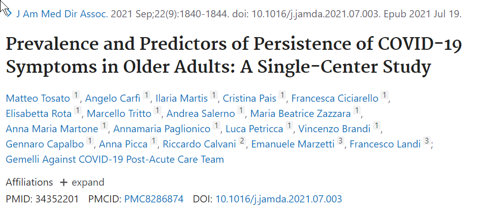

Figure 1: Tosato et al 2021, PMID: 34352201

## Tosato 2021, PMID: 34352201, part 2

Symptom persistence weeks after laboratory-confirmed severe acute respiratory syndrome coronavirus 2 (SARS-CoV-2) clearance is a relatively common long-term complication of Coronavirus disease 2019 (COVID-19). Little is known about this phenomenon in older adults. The present study aimed at determining the prevalence of persistent symptoms among older COVID-19 survivors and identifying symptom patterns.

## Tosato 2021, PMID: 34352201, part 3

- The mean age was 73.1 ± 6.2 years
  - 73 - 2 * 6 = 61
  - 73 + 2 * 6 = 85
- The average time elapsed from hospital discharge was 76.8 ± 20.3 days
  - 77 - 2 * 20 = 37
  - 77 + 2 * 20 = 117

## Why is variation important

- Variation = Noise
  - Too much noise can hide signals
- Variation = Heterogeneity
  - Too little heterogeneity, hard to generalize
  - Too much heterogeneity, mixing apples and oranges
- Variation = Unpredictability
  - Too much unpredictability, hard to prepare for the future
- Variation = Risk
  - Too much risk can create a financial burden

## Should you try to minimize variation?

- Yes, for early studies
  - Easier to detect signals
  - Proof of concept trials
- No, for later studies
  - Easier to generalize results
  - Pragmatic trials

## Break #5

- What you have learned
  - Standard deviation
- What’s coming next
  - Computing means and standard deviations in R

## Live demo, part 2

## Summary

- What you have learned
  - Counts and percentages
  - Computing counts and percentages using R
  - Mean and median
  - Percentiles
  - Standard deviation
  - Computing means and standard deviations in R